# {col2hcl}

Author

Nicholas Vietto

# Intro

This is a super fast way to look up hexcode colors in R. Normally you’d have to head to a page like [this](https://www.nceas.ucsb.edu/sites/default/files/2020-04/colorPaletteCheatsheet.pdf) and squint until you find a color code that works. But there’s another way thanks to the {Scales} package.

# Steps and Vignette

**Install**

```r
# install.packages("scales")

library(scales)
```

## One color

**Find a color**

```r
colors(distinct = TRUE)
```

```
  [1] "white"                "aliceblue"            "antiquewhite"
  [4] "antiquewhite1"        "antiquewhite2"        "antiquewhite3"
  [7] "antiquewhite4"        "aquamarine"           "aquamarine2"
 [10] "aquamarine3"          "aquamarine4"          "azure"
 [13] "azure2"               "azure3"               "azure4"
 [16] "beige"                "bisque"               "bisque2"
 [19] "bisque3"              "bisque4"              "black"
 [22] "blanchedalmond"       "blue"                 "blue2"
 [25] "blue3"                "blue4"                "blueviolet"
 [28] "brown"                "brown1"               "brown2"
 [31] "brown3"               "brown4"               "burlywood"
 [34] "burlywood1"           "burlywood2"           "burlywood3"
 [37] "burlywood4"           "cadetblue"            "cadetblue1"
 [40] "cadetblue2"           "cadetblue3"           "cadetblue4"
 [43] "chartreuse"           "chartreuse2"          "chartreuse3"
```

[output cut: 153 more lines]

**Use show_col and col2hcl**

If you know the color already.

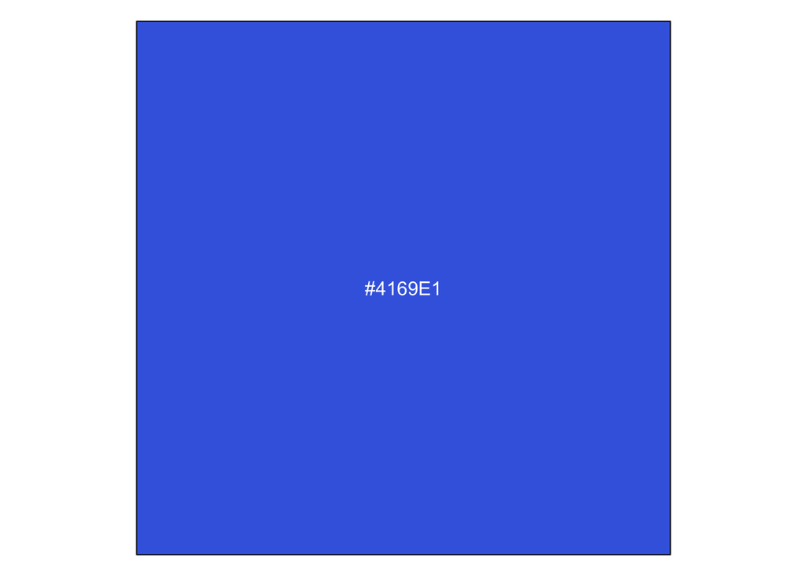

```r
show_col(col2hcl("royalblue"))
```

## More than one color

### Hue

If you want to vary the color slightly use the *Hue* argument.

**Click to find out the definition of “Hue” 🙈**

Hue literally mean color 🙉

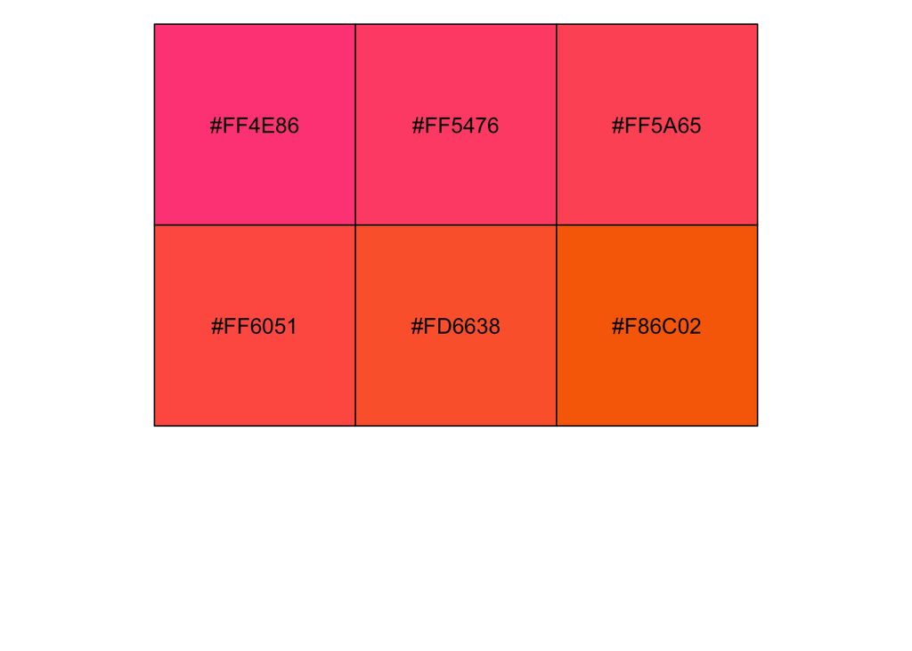

```r
#🍅

tomatoes <- rep("tomato", 6) # we have to create a vector here to allow multiple to show
show_col(col2hcl(tomatoes, h = seq( 0, 25, length = 6)))
```

Lets break this down.

*show_col* allows the visualization to occur in R

*col2hcl* is the function that gives us the hex codes

- within this argument we throw in our vector (i.e, our 🍅)
- Then we can modify our hue a bit wtih *seq* and any number between [0, 360]
- Keep the 0 in the beginning, and if you want a lot of similar colors keep the next number (or the range between the two) small.

*length* this just lets R know how many color we want to show.

### Chroma

If you want the intensity to change we can use the *chroma* argument.

We use the identical process as before this time we use “c”. The range for chroma is [0, 100]

**Note**

We already created an our *tomatoes* object so we don’t have to redefine it.

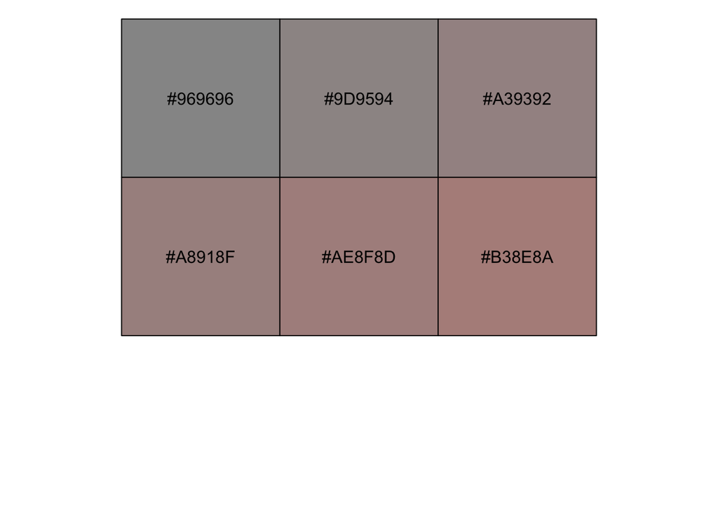

```r
show_col(col2hcl(tomatoes, c = seq( 0, 25, length = 6)))
```

Let max the argument out and see what happens

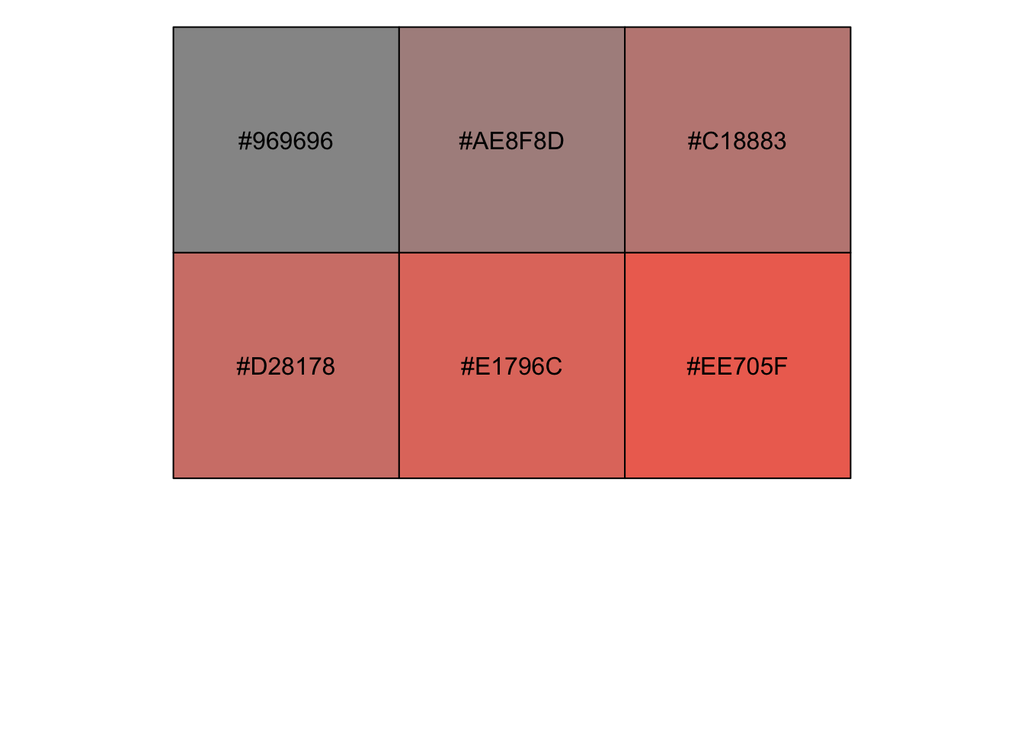

```r
show_col(col2hcl(tomatoes, c = seq( 0, 100, length = 6)))
```

### Luminance

If we want to look at variations in the intensity of light of our 🍅s we can use the *l* argument.

Our luminescence range is [0, 100]

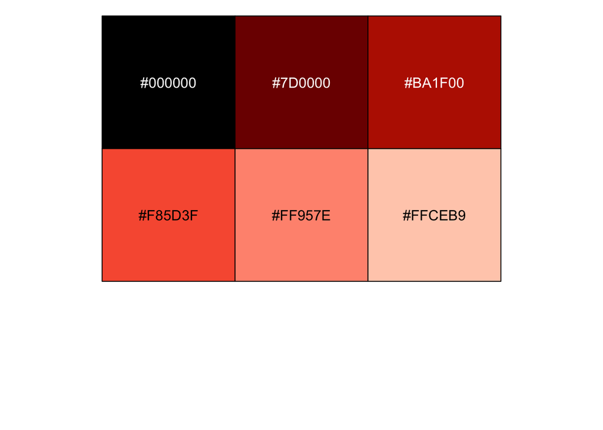

```r
show_col(col2hcl(tomatoes, l = seq( 0, 100, length = 6)))
```

Hope that helps!

# References

[Modify standard R colour in hcl colour space](https://scales.r-lib.org/reference/col2hcl.html#ref-examples)